# Exploration des données sur les prêts prospères

# Analyse préliminaire

Cet ensemble de données contient des informations sur les prêts entre pairs facilités par la société de crédit Prosper

```python
# importer tous les packages
import pandas as pd
import numpy as np
import matplotlib.pyplot as plt
import seaborn as sns

%matplotlib inline
```

```python
# Lecture des données
df_loan = pd.read_csv('prosperLoanData.csv')
```

```python
# Lecture des 5 premières lignes des données
df_loan.head()
```

|  | ListingKey | ListingNumber | ListingCreationDate | CreditGrade | Term | LoanStatus | ClosedDate | BorrowerAPR | BorrowerRate | LenderYield | ... | LP_ServiceFees | LP_CollectionFees | LP_GrossPrincipalLoss | LP_NetPrincipalLoss | LP_NonPrincipalRecoverypayments | PercentFunded | Recommendations | InvestmentFromFriendsCount | InvestmentFromFriendsAmount | Investors |
| --- | --- | --- | --- | --- | --- | --- | --- | --- | --- | --- | --- | --- | --- | --- | --- | --- | --- | --- | --- | --- | --- |
| 0 | 1021339766868145413AB3B | 193129 | 2007-08-26 19:09:29.263000000 | C | 36 | Completed | 2009-08-14 00:00:00 | 0.16516 | 0.1580 | 0.1380 | ... | -133.18 | 0.0 | 0.0 | 0.0 | 0.0 | 1.0 | 0 | 0 | 0.0 | 258 |
| 1 | 10273602499503308B223C1 | 1209647 | 2014-02-27 08:28:07.900000000 | NaN | 36 | Current | NaN | 0.12016 | 0.0920 | 0.0820 | ... | 0.00 | 0.0 | 0.0 | 0.0 | 0.0 | 1.0 | 0 | 0 | 0.0 | 1 |
| 2 | 0EE9337825851032864889A | 81716 | 2007-01-05 15:00:47.090000000 | HR | 36 | Completed | 2009-12-17 00:00:00 | 0.28269 | 0.2750 | 0.2400 | ... | -24.20 | 0.0 | 0.0 | 0.0 | 0.0 | 1.0 | 0 | 0 | 0.0 | 41 |
| 3 | 0EF5356002482715299901A | 658116 | 2012-10-22 11:02:35.010000000 | NaN | 36 | Current | NaN | 0.12528 | 0.0974 | 0.0874 | ... | -108.01 | 0.0 | 0.0 | 0.0 | 0.0 | 1.0 | 0 | 0 | 0.0 | 158 |
| 4 | 0F023589499656230C5E3E2 | 909464 | 2013-09-14 18:38:39.097000000 | NaN | 36 | Current | NaN | 0.24614 | 0.2085 | 0.1985 | ... | -60.27 | 0.0 | 0.0 | 0.0 | 0.0 | 1.0 | 0 | 0 | 0.0 | 20 |

5 rows × 81 columns

```python
# Affichage de la structure des données
df_loan.info()
```

```
<class 'pandas.core.frame.DataFrame'>
RangeIndex: 113937 entries, 0 to 113936
Data columns (total 81 columns):
 #   Column                               Non-Null Count   Dtype
---  ------                               --------------   -----
 0   ListingKey                           113937 non-null  object
 1   ListingNumber                        113937 non-null  int64
 2   ListingCreationDate                  113937 non-null  object
 3   CreditGrade                          28953 non-null   object
 4   Term                                 113937 non-null  int64
 5   LoanStatus                           113937 non-null  object
 6   ClosedDate                           55089 non-null   object
 7   BorrowerAPR                          113912 non-null  float64
 8   BorrowerRate                         113937 non-null  float64
 9   LenderYield                          113937 non-null  float64
```

[output cut: 73 more lines]

```python
# Affichage des statistiques descriptives du jeu de données
df_loan.describe()
```

|  | ListingNumber | Term | BorrowerAPR | BorrowerRate | LenderYield | EstimatedEffectiveYield | EstimatedLoss | EstimatedReturn | ProsperRating (numeric) | ProsperScore | ... | LP_ServiceFees | LP_CollectionFees | LP_GrossPrincipalLoss | LP_NetPrincipalLoss | LP_NonPrincipalRecoverypayments | PercentFunded | Recommendations | InvestmentFromFriendsCount | InvestmentFromFriendsAmount | Investors |
| --- | --- | --- | --- | --- | --- | --- | --- | --- | --- | --- | --- | --- | --- | --- | --- | --- | --- | --- | --- | --- | --- |
| count | 1.139370e+05 | 113937.000000 | 113912.000000 | 113937.000000 | 113937.000000 | 84853.000000 | 84853.000000 | 84853.000000 | 84853.000000 | 84853.000000 | ... | 113937.000000 | 113937.000000 | 113937.000000 | 113937.000000 | 113937.000000 | 113937.000000 | 113937.000000 | 113937.000000 | 113937.000000 | 113937.000000 |
| mean | 6.278857e+05 | 40.830248 | 0.218828 | 0.192764 | 0.182701 | 0.168661 | 0.080306 | 0.096068 | 4.072243 | 5.950067 | ... | -54.725641 | -14.242698 | 700.446342 | 681.420499 | 25.142686 | 0.998584 | 0.048027 | 0.023460 | 16.550751 | 80.475228 |
| std | 3.280762e+05 | 10.436212 | 0.080364 | 0.074818 | 0.074516 | 0.068467 | 0.046764 | 0.030403 | 1.673227 | 2.376501 | ... | 60.675425 | 109.232758 | 2388.513831 | 2357.167068 | 275.657937 | 0.017919 | 0.332353 | 0.232412 | 294.545422 | 103.239020 |
| min | 4.000000e+00 | 12.000000 | 0.006530 | 0.000000 | -0.010000 | -0.182700 | 0.004900 | -0.182700 | 1.000000 | 1.000000 | ... | -664.870000 | -9274.750000 | -94.200000 | -954.550000 | 0.000000 | 0.700000 | 0.000000 | 0.000000 | 0.000000 | 1.000000 |
| 25% | 4.009190e+05 | 36.000000 | 0.156290 | 0.134000 | 0.124200 | 0.115670 | 0.042400 | 0.074080 | 3.000000 | 4.000000 | ... | -73.180000 | 0.000000 | 0.000000 | 0.000000 | 0.000000 | 1.000000 | 0.000000 | 0.000000 | 0.000000 | 2.000000 |
| 50% | 6.005540e+05 | 36.000000 | 0.209760 | 0.184000 | 0.173000 | 0.161500 | 0.072400 | 0.091700 | 4.000000 | 6.000000 | ... | -34.440000 | 0.000000 | 0.000000 | 0.000000 | 0.000000 | 1.000000 | 0.000000 | 0.000000 | 0.000000 | 44.000000 |
| 75% | 8.926340e+05 | 36.000000 | 0.283810 | 0.250000 | 0.240000 | 0.224300 | 0.112000 | 0.116600 | 5.000000 | 8.000000 | ... | -13.920000 | 0.000000 | 0.000000 | 0.000000 | 0.000000 | 1.000000 | 0.000000 | 0.000000 | 0.000000 | 115.000000 |
| max | 1.255725e+06 | 60.000000 | 0.512290 | 0.497500 | 0.492500 | 0.319900 | 0.366000 | 0.283700 | 7.000000 | 11.000000 | ... | 32.060000 | 0.000000 | 25000.000000 | 25000.000000 | 21117.900000 | 1.012500 | 39.000000 | 33.000000 | 25000.000000 | 1189.000000 |

8 rows × 61 columns

```python
# Affichage d'un échantillon de 10 lignes du jeu de données
df_loan.sample(10)
```

|  | ListingKey | ListingNumber | ListingCreationDate | CreditGrade | Term | LoanStatus | ClosedDate | BorrowerAPR | BorrowerRate | LenderYield | ... | LP_ServiceFees | LP_CollectionFees | LP_GrossPrincipalLoss | LP_NetPrincipalLoss | LP_NonPrincipalRecoverypayments | PercentFunded | Recommendations | InvestmentFromFriendsCount | InvestmentFromFriendsAmount | Investors |
| --- | --- | --- | --- | --- | --- | --- | --- | --- | --- | --- | --- | --- | --- | --- | --- | --- | --- | --- | --- | --- | --- |
| 193 | 0F6133644711535583E92C3 | 17091 | 2006-05-31 23:48:17.177000000 | E | 36 | Defaulted | 2007-10-08 00:00:00 | 0.23937 | 0.2300 | 0.2250 | ... | -8.71 | 0.0 | 1590.40 | 1584.56 | 0.0 | 1.0 | 0 | 0 | 0.0 | 13 |
| 1693 | 7B0B3538204771666D52573 | 554812 | 2012-01-27 20:03:49.283000000 | NaN | 36 | Current | NaN | 0.35797 | 0.3177 | 0.3077 | ... | -60.98 | 0.0 | 0.00 | 0.00 | 0.0 | 1.0 | 0 | 0 | 0.0 | 1 |
| 55626 | 1FCB35512857235687207BA | 606825 | 2012-07-02 19:18:57.863000000 | NaN | 60 | Chargedoff | 2013-02-11 00:00:00 | 0.35838 | 0.3304 | 0.3204 | ... | -5.08 | 0.0 | 2962.36 | 2962.36 | 0.0 | 1.0 | 0 | 0 | 0.0 | 52 |
| 9520 | 0C2A3561181741873964B32 | 659221 | 2012-10-23 06:29:24.910000000 | NaN | 60 | Current | NaN | 0.25861 | 0.2333 | 0.2233 | ... | -233.17 | 0.0 | 0.00 | 0.00 | 0.0 | 1.0 | 0 | 0 | 0.0 | 136 |
| 90030 | C9793596804588337C005AA | 1058506 | 2013-12-19 10:30:52.603000000 | NaN | 36 | Current | NaN | 0.14206 | 0.1139 | 0.1039 | ... | -41.97 | 0.0 | 0.00 | 0.00 | 0.0 | 1.0 | 0 | 0 | 0.0 | 1 |
| 10871 | 9DD5348783490835685CA72 | 465082 | 2010-07-05 11:32:17.663000000 | NaN | 36 | Completed | 2013-07-15 00:00:00 | 0.19954 | 0.1750 | 0.1650 | ... | -25.11 | 0.0 | 0.00 | 0.00 | 0.0 | 1.0 | 0 | 0 | 0.0 | 97 |
| 31243 | C22535520530749397409BE | 607717 | 2012-07-05 07:50:29.750000000 | NaN | 12 | Completed | 2013-07-10 00:00:00 | 0.09986 | 0.0628 | 0.0528 | ... | -49.40 | 0.0 | 0.00 | 0.00 | 0.0 | 1.0 | 0 | 0 | 0.0 | 188 |
| 80211 | 1CCE3514222402677A3A6C2 | 506135 | 2011-05-10 06:49:28.857000000 | NaN | 36 | Current | NaN | 0.20321 | 0.1699 | 0.1599 | ... | -213.11 | 0.0 | 0.00 | 0.00 | 0.0 | 1.0 | 0 | 0 | 0.0 | 132 |
| 10118 | E1E7339137794657061D3C1 | 147817 | 2007-06-06 12:45:17.360000000 | E | 36 | Defaulted | 2008-06-15 00:00:00 | 0.22489 | 0.2100 | 0.1900 | ... | -46.48 | 0.0 | 6866.16 | 6866.16 | 0.0 | 1.0 | 0 | 0 | 0.0 | 227 |
| 96141 | 2B4B3497672399085B287C9 | 479099 | 2010-10-11 16:10:55.247000000 | NaN | 36 | Completed | 2013-10-29 00:00:00 | 0.38058 | 0.3435 | 0.3335 | ... | -36.03 | 0.0 | 0.00 | 0.00 | 0.0 | 1.0 | 0 | 0 | 0.0 | 72 |

10 rows × 81 columns

Notez que cet ensemble de données contient 81 colonnes. Pour faire de cette analyse, j'ai pris les colonnes suivantes :

```python
# Liste des colonnes de sorties pour l'analyse
columns_output =  [
    'Term', 'LoanStatus', 'BorrowerRate', 'ProsperRating (Alpha)', 'ListingCategory (numeric)', 'EmploymentStatus',
    'DelinquenciesLast7Years', 'StatedMonthlyIncome', 'TotalProsperLoans', 'LoanOriginalAmount',
    'LoanOriginationDate', 'Recommendations', 'Investors'
]
```

```python
# Nouveau Jeu de données avec les colonnes à utiliser pour l'analyse
df_output = df_loan[columns_output]
```

```python
# Affichage d'un échantillon de 10 lignes du jeu de données à analyser
df_output.sample(10)
```

|  | Term | LoanStatus | BorrowerRate | ProsperRating (Alpha) | ListingCategory (numeric) | EmploymentStatus | DelinquenciesLast7Years | StatedMonthlyIncome | TotalProsperLoans | LoanOriginalAmount | LoanOriginationDate | Recommendations | Investors |
| --- | --- | --- | --- | --- | --- | --- | --- | --- | --- | --- | --- | --- | --- |
| 26331 | 36 | Chargedoff | 0.2400 | NaN | 0 | Full-time | 21.0 | 2833.333333 | NaN | 2700 | 2007-08-29 00:00:00 | 0 | 32 |
| 89610 | 36 | Current | 0.1620 | B | 1 | Employed | 10.0 | 6250.000000 | NaN | 10000 | 2013-10-25 00:00:00 | 0 | 1 |
| 87935 | 60 | Completed | 0.2624 | D | 13 | Self-employed | 0.0 | 2500.000000 | NaN | 8413 | 2012-12-24 00:00:00 | 0 | 66 |
| 2018 | 36 | Completed | 0.1395 | NaN | 0 | Full-time | 14.0 | 2916.666667 | NaN | 4000 | 2007-03-20 00:00:00 | 1 | 206 |
| 37921 | 60 | Current | 0.1980 | C | 1 | Employed | 0.0 | 8265.416667 | NaN | 25000 | 2013-10-17 00:00:00 | 0 | 1 |
| 100751 | 36 | Current | 0.2346 | D | 13 | Employed | 0.0 | 6666.666667 | NaN | 3000 | 2013-04-18 00:00:00 | 0 | 3 |
| 35318 | 36 | Current | 0.1314 | B | 1 | Employed | 8.0 | 4324.916667 | NaN | 15000 | 2013-11-26 00:00:00 | 0 | 1 |
| 44630 | 60 | Current | 0.2705 | D | 1 | Employed | 7.0 | 7500.000000 | 1.0 | 10000 | 2012-03-14 00:00:00 | 0 | 19 |
| 71148 | 36 | Completed | 0.0875 | NaN | 0 | Not available | 0.0 | 629.000000 | NaN | 1500 | 2006-12-07 00:00:00 | 0 | 33 |
| 12275 | 36 | Current | 0.1585 | C | 1 | Employed | 0.0 | 6666.666667 | 1.0 | 9000 | 2013-11-27 00:00:00 | 0 | 13 |

```python
# Affichage de la structure du jeu de données pour analyse
df_output.info()
```

```
<class 'pandas.core.frame.DataFrame'>
RangeIndex: 113937 entries, 0 to 113936
Data columns (total 13 columns):
 #   Column                     Non-Null Count   Dtype
---  ------                     --------------   -----
 0   Term                       113937 non-null  int64
 1   LoanStatus                 113937 non-null  object
 2   BorrowerRate               113937 non-null  float64
 3   ProsperRating (Alpha)      84853 non-null   object
 4   ListingCategory (numeric)  113937 non-null  int64
 5   EmploymentStatus           111682 non-null  object
 6   DelinquenciesLast7Years    112947 non-null  float64
 7   StatedMonthlyIncome        113937 non-null  float64
 8   TotalProsperLoans          22085 non-null   float64
 9   LoanOriginalAmount         113937 non-null  int64
 10  LoanOriginationDate        113937 non-null  object
 11  Recommendations            113937 non-null  int64
 12  Investors                  113937 non-null  int64
dtypes: float64(4), int64(5), object(4)
memory usage: 11.3+ MB
```

```python
# Affichage des statistiques descriptives du jeu de données pour analyse
df_output.describe()
```

|  | Term | BorrowerRate | ListingCategory (numeric) | DelinquenciesLast7Years | StatedMonthlyIncome | TotalProsperLoans | LoanOriginalAmount | Recommendations | Investors |
| --- | --- | --- | --- | --- | --- | --- | --- | --- | --- |
| count | 113937.000000 | 113937.000000 | 113937.000000 | 112947.000000 | 1.139370e+05 | 22085.000000 | 113937.00000 | 113937.000000 | 113937.000000 |
| mean | 40.830248 | 0.192764 | 2.774209 | 4.154984 | 5.608026e+03 | 1.421100 | 8337.01385 | 0.048027 | 80.475228 |
| std | 10.436212 | 0.074818 | 3.996797 | 10.160216 | 7.478497e+03 | 0.764042 | 6245.80058 | 0.332353 | 103.239020 |
| min | 12.000000 | 0.000000 | 0.000000 | 0.000000 | 0.000000e+00 | 0.000000 | 1000.00000 | 0.000000 | 1.000000 |
| 25% | 36.000000 | 0.134000 | 1.000000 | 0.000000 | 3.200333e+03 | 1.000000 | 4000.00000 | 0.000000 | 2.000000 |
| 50% | 36.000000 | 0.184000 | 1.000000 | 0.000000 | 4.666667e+03 | 1.000000 | 6500.00000 | 0.000000 | 44.000000 |
| 75% | 36.000000 | 0.250000 | 3.000000 | 3.000000 | 6.825000e+03 | 2.000000 | 12000.00000 | 0.000000 | 115.000000 |
| max | 60.000000 | 0.497500 | 20.000000 | 99.000000 | 1.750003e+06 | 8.000000 | 35000.00000 | 39.000000 | 1189.000000 |

Étant donné que Prosper n'utilise son propre classement Prosper que depuis 2009, nous avons beaucoup de valeurs manquantes dans la colonne ProsperRating. Supprimons ses valeurs manquantes :

```python
# Suppression des données manquantes de la colonne ProsperRating
df_output = df_output.dropna(subset=['ProsperRating (Alpha)']).reset_index()
```

Convertissons LoanOriginationDate en type de données datetime :

```python
# Conversion du format de la colonne LoanOriginationDate
df_output['LoanOriginationDate'] = pd.to_datetime(df_output['LoanOriginationDate'])
```

```python
# Remplacer les données manquantes de la colonne TotalProsperLoans par zéro
df_output['TotalProsperLoans'] = df_output['TotalProsperLoans'].fillna(0)
```

```python
# Vérification de la structure du jeu de données
df_output.info()
```

```
<class 'pandas.core.frame.DataFrame'>
RangeIndex: 84853 entries, 0 to 84852
Data columns (total 14 columns):
 #   Column                     Non-Null Count  Dtype
---  ------                     --------------  -----
 0   index                      84853 non-null  int64
 1   Term                       84853 non-null  int64
 2   LoanStatus                 84853 non-null  object
 3   BorrowerRate               84853 non-null  float64
 4   ProsperRating (Alpha)      84853 non-null  object
 5   ListingCategory (numeric)  84853 non-null  int64
 6   EmploymentStatus           84853 non-null  object
 7   DelinquenciesLast7Years    84853 non-null  float64
 8   StatedMonthlyIncome        84853 non-null  float64
 9   TotalProsperLoans          84853 non-null  float64
 10  LoanOriginalAmount         84853 non-null  int64
 11  LoanOriginationDate        84853 non-null  datetime64[ns]
 12  Recommendations            84853 non-null  int64
 13  Investors                  84853 non-null  int64
dtypes: datetime64[ns](1), float64(4), int64(6), object(3)
memory usage: 9.1+ MB
```

### Quelle(s) est/sont la/les principale(s) caractéristique(s) d'intérêt dans votre jeu de données ?

Essayons de comprendre quelles fonctionnalités pouvant être utilisées pour prédire le défaut de crédit. Aussi, nous voudrons vérifier quels sont les principaux facteurs liés à la prospérité de la côte de crédit.

### À votre avis, quelles fonctionnalités de l'ensemble de données vous aideront à étayer votre enquête sur les fonctionnalités qui vous intéressent ?

Nous pensons que la note Prosper des emprunteurs aura le plus grand impact sur les risques de défaut. Nous nous attendons également à ce que le montant du prêt joue un rôle majeur et peut-être la catégorie de crédit. La note de prospérité dépendra du revenu déclaré et du statut d'emploi.

## Exploration univariée

### Statut du prêt

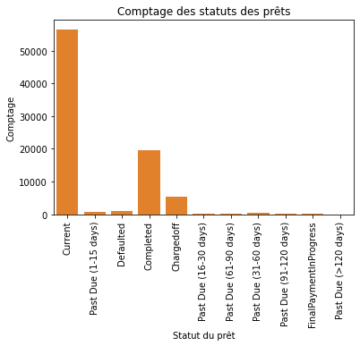

```python
# Affichage le nombre d'observations dans chaque groupe catégoriel de la colonne LoanStatus
base_color = sns.color_palette()[1]
plt.xticks(rotation=90)
sns.countplot(data = df_output, x = 'LoanStatus', color = base_color);
plt.ylabel('Comptage')
plt.xlabel('Statut du prêt')
plt.title('Comptage des statuts des prêts')
```

**Constat 1 :**

- La plupart des prêts dans l'ensemble de données sont en fait des prêts en cours.
- Les prêts en souffrance sont divisés en plusieurs groupes en fonction de la durée du retard de paiement.
- L'autre grande partie est constituée de prêts achevés, les prêts en défaut compromettent une minorité, mais les prêts radiés compromettent également un montant substantiel.

### Statut d'emploi

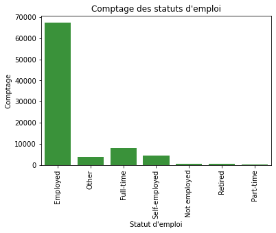

```python
# Affichage le nombre d'observations dans chaque groupe catégoriel de la colonne EmploymentStatus
base_color = sns.color_palette()[2]
sns.countplot(data = df_output, x = 'EmploymentStatus', color = base_color);
plt.xticks(rotation = 90);
plt.ylabel('Comptage')
plt.xlabel("Statut d'emploi")
plt.title("Comptage des statuts d'emploi")
```

**Constat 2 :**

- La majorité des emprunteurs sont employés et toutes les autres catégories représentent une petite partie des emprunteurs.
- En petit groupe, le temps plein est le plus élevé, après quoi les travailleurs indépendants sont là et ainsi de suite.

### Revenu mensuel déclaré

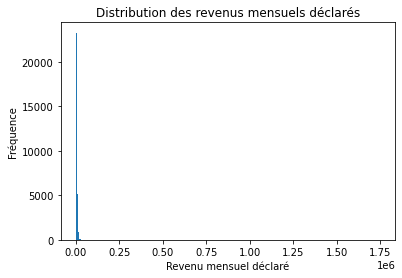

```python
# Affichage de l'histogramme de la colonne StatedMonthlyIncome
plt.hist(data=df_output, x='StatedMonthlyIncome', bins=1000);
plt.ylabel('Fréquence')
plt.xlabel("Revenu mensuel déclaré")
plt.title("Distribution des revenus mensuels déclarés")
```

(**Remarque** : la distribution du revenu mensuel déclaré est fortement biaisée vers la droite. Nous devons donc vérifier le nombre de valeurs aberrantes)

```python
# Affichage du nombre de valeurs aberrantes
stated_monthly_income_std = df_output['StatedMonthlyIncome'].std()
stated_monthly_income_mean = df_output['StatedMonthlyIncome'].mean()
boundary = stated_monthly_income_mean + stated_monthly_income_std * 3
len(df_output[df_output['StatedMonthlyIncome'] >= boundary])
```

```
245
```

**Après avoir zoomé sur le graphique, nous obtenons ceci**

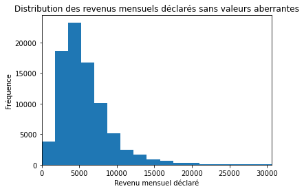

```python
# Distribution de la colonne StatedMonthlyIncome sans valeurs aberrantes
plt.hist(data=df_output, x='StatedMonthlyIncome', bins=1000);
plt.xlim(0, boundary);
plt.ylabel('Fréquence')
plt.xlabel("Revenu mensuel déclaré")
plt.title("Distribution des revenus mensuels déclarés sans valeurs aberrantes")
```

**Constat 3 :**

- Avec une limite de moyenne et 3 fois les écarts-types, la distribution du revenu mensuel a toujours un biais vers la droite notable, mais nous pouvons maintenant voir que le mode est d'environ 5000.

### Discutez de la ou des distributions de vos variables d'intérêt. Y avait-il des points inhabituels ? Avez-vous eu besoin d'effectuer des transformations ?

La distribution des revenus déclarés mensuels est très **maladroite** : avec beaucoup de valeurs aberrantes et une très large plage, mais c'était quand même biaisé. La majorité des emprunteurs sont employés et toutes les autres catégories comme une petite partie des emprunteurs et la plupart des prêts dans l'ensemble de données sont en fait des prêts en cours.

### Parmi les fonctionnalités que vous avez étudiées, y avait-il des distributions inhabituelles ? Avez-vous effectué des opérations sur les données pour ranger, ajuster ou modifier la forme des données ? Si oui, pourquoi avez-vous fait cela ?

La majorité des crédits sont en réalité des crédits en cours. Étant donné que notre objectif principal est de définir les facteurs déterminants du résultat du prêt, nous ne sommes pas intéressés par les prêts en cours.

## Exploration bivariée

```python
# Ajustage de la forme des données
condition = (df_output['LoanStatus'] == 'Completed') | (df_output['LoanStatus'] == 'Defaulted') |\
                  (df_output['LoanStatus'] == 'Chargedoff')
df_output = df_output[condition]

def default_change(row):
    if row['LoanStatus'] == 'Chargedoff':
        return 'Defaulted'
    else:
        return row['LoanStatus']

df_output['LoanStatus'] = df_output.apply(default_change, axis=1)
df_output['LoanStatus'].value_counts()
```

```
Completed    19664
Defaulted     6341
Name: LoanStatus, dtype: int64
```

**Après transformation de l'ensemble de données, nous avons 19664 prêts terminés et 6341 en défaut.**

```python
# Réduction du nombre de catégories
categories = {1: 'Debt Consolidation', 2: 'Home Improvement', 3: 'Business', 6: 'Auto', 7: 'Other'}
def reduce_categorie(row):
    loan_category = row['ListingCategory (numeric)']
    if  loan_category in categories:
        return categories[loan_category]
    else:
        return categories[7]

df_output['ListingCategory (numeric)'] = df_output.apply(reduce_categorie, axis=1)
df_output['ListingCategory (numeric)'].value_counts()
```

```
Debt Consolidation    12740
Other                  7083
Home Improvement       2612
Business               2366
Auto                   1204
Name: ListingCategory (numeric), dtype: int64
```

**La catégorie de liste de variables est configurée en tant que numérique et la plupart des valeurs ont une fréquence très basse, pour une visualisation plus facile, nous l'avons donc changée en catégorie et réduit le nombre de catégories.**

### Statut et note de prospérité

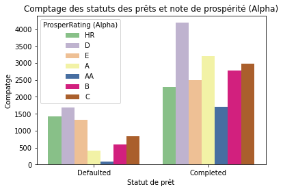

```python
# Affichage le nombre d'observations dans chaque groupe catégoriel les colonnes LoanStatus et ProsperRating (Alpha)
sns.countplot(data = df_output, x = 'LoanStatus', hue = 'ProsperRating (Alpha)', palette = 'Accent')
plt.ylabel('Compatge')
plt.xlabel("Statut de prêt")
plt.title("Comptage des statuts des prêts et note de prospérité (Alpha)")
```

**Constat 1 :**

- La note la plus fréquente parmi les prêts en défaut est en fait "D".
- Et la note la plus fréquente parmi les terminés est également "D" et la deuxième plus élevée est "A" et ainsi de suite.

### Début de Crédit avec la catégorie d'inscription

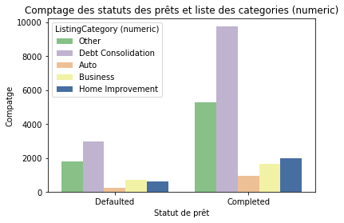

```python
# Affichage le nombre d'observations dans chaque groupe catégoriel de la colonne LoanStatus et ListingCategory (numeric)
sns.countplot(data = df_output, x = 'LoanStatus', hue = 'ListingCategory (numeric)', palette = 'Accent')
plt.ylabel('Compatge')
plt.xlabel("Statut de prêt")
plt.title("Comptage des statuts des prêts et liste des categories (numeric)")
```

**Constat 2 :**

- Dans les deux graphiques, "consolidation de la dette" a la plus grande fréquence parmi tous.

### Statut du prêt et montant du prêt

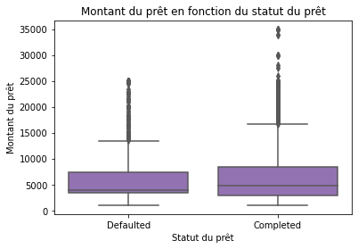

```python
# Affichage du diagramme en boîte et moustaches pour la colonne LoanStatus
base_color = sns.color_palette()[4]
sns.boxplot(data = df_output, x = 'LoanStatus', y = 'LoanOriginalAmount', color = base_color);
plt.xlabel('Statut du prêt')
plt.ylabel("Montant du prêt")
plt.title("Montant du prêt en fonction du statut du prêt")
```

**Constat 3 :**

- À partir du graphique ci-dessus, nous pouvons affirmer que les "crédits en défaut" ont tendance à être plus petits que les "crédits terminés".

### Note de prospérité et statut d'emploi

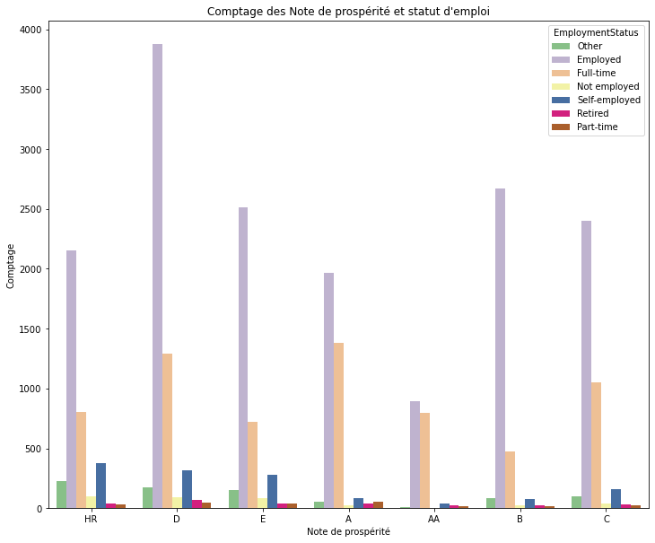

```python
# Affichage le nombre d'observations dans chaque groupe catégoriel de la colonne ProsperRating (Alpha) et EmploymentStatus
plt.figure(figsize = [12, 10])
sns.countplot(data = df_output, x = 'ProsperRating (Alpha)', hue = 'EmploymentStatus', palette = 'Accent');
plt.ylabel('Comptage')
plt.xlabel("Note de prospérité")
plt.title("Comptage des Note de prospérité et statut d'emploi")
```

**Constat 4 :**

- Les côtes inférieures semblent avoir de plus grandes proportions de personnes ayant le statut d'emploi "Sans emploi", "Travailleur indépendant", "Retraité" et "Temps partiel".

### Parlez de certaines des relations que vous avez observées dans cette partie de l'enquête. Comment la ou les caractéristiques d'intérêt ont-elles varié avec d'autres caractéristiques de l'ensemble de données ?

Dans le statut du prêt par rapport au montant du prêt, les crédits en défaut ont tendance à être plus petits que les crédits achevés une fois. Le statut d'emploi des personnes ayant des côtes inférieures tend à être "Sans emploi", "Travailleur indépendant", "Retraité" ou "Temps partiel".

### Avez-vous observé des relations intéressantes entre les autres fonctionnalités (pas la ou les principales fonctionnalités d'intérêt) ?

La note de prospérité "D" est la note la plus fréquente parmi les crédits en défaut.

## Exploration multivariée

### Notation, montant du prêt et statut du prêt

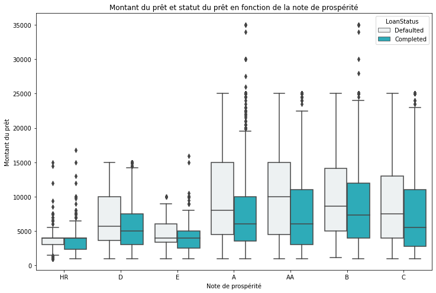

```python
# Affichage du diagramme en boîte et moustaches pour la colonne ProsperRating
base_color = sns.color_palette()[9]
plt.figure(figsize = [12, 8])
sns.boxplot(data=df_output, x='ProsperRating (Alpha)', y='LoanOriginalAmount', hue='LoanStatus', color = base_color);
plt.ylabel('Montant du prêt')
plt.xlabel("Note de prospérité")
plt.title("Montant du prêt et statut du prêt en fonction de la note de prospérité")
```

**Constat 1 :**

- À l'exception des notes les plus basses, les crédits en défaut ont tendance à être plus importants que les crédits achevés.
- La plupart des crédits en défaut proviennent de personnes ayant une faible cote Prosper.

### Relations entre la catégorie de crédit, la cote de crédit et le résultat du crédit

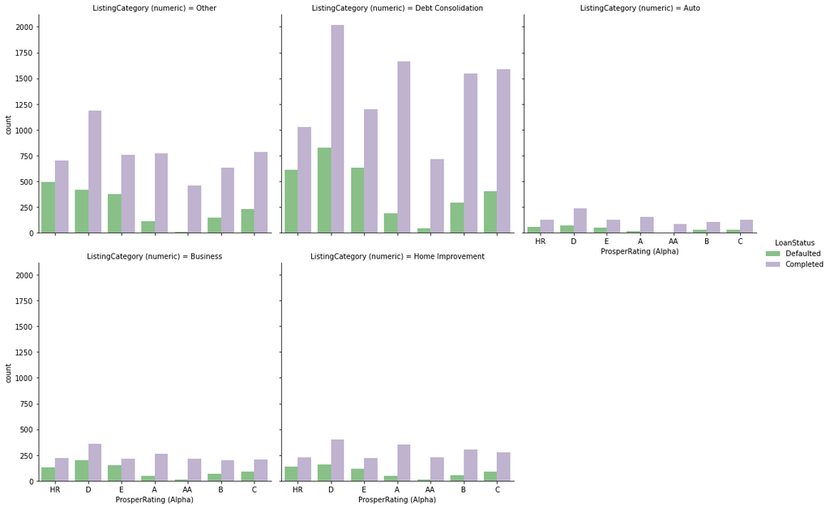

```python
# Diagrammes pour illustrer la relation entre les colonnes ProsperRating, LoanStatus et ListingCategory
sns.catplot(x = 'ProsperRating (Alpha)', hue = 'LoanStatus', col = 'ListingCategory (numeric)',
              data = df_output, kind = 'count', palette = 'Accent', col_wrap = 3);
```

**Constat 2 :**

- Il y a 5 graphiques dans le second qui ont beaucoup de hauts et de bas autres que tous.
- Il n'y a pas de différence substantielle pour les taux de défaut dans les différentes catégories ventilées par notation.

### Relations entre Montant de prêt, catégorie de prêt et statut du prêt

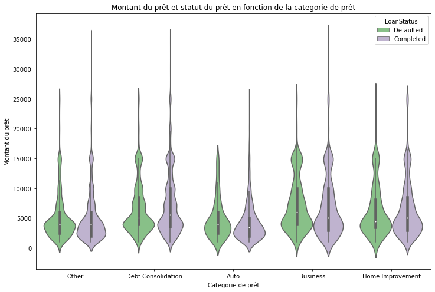

```python
# Diagramme pour présenter les interactions entre les colonnes ListingCategory, LoanStatus et LoanOriginalAmount
plt.figure(figsize = [12, 8])
sns.violinplot(data=df_output, x='ListingCategory (numeric)', y='LoanOriginalAmount', hue='LoanStatus', palette = 'Accent');
plt.ylabel('Montant du prêt')
plt.xlabel("Categorie de prêt")
plt.title("Montant du prêt et statut du prêt en fonction de la categorie de prêt")
```

**Constat 3 :**

- À l'exception de l'automobile, les entreprises et l'amélioration de l'habitat n'ont pas une moyenne presque égale entre eux.
- La catégorie d'entreprise a tendance à avoir un montant plus élevé.

### Parlez de certaines des relations que vous avez observées dans cette partie de l'enquête. Y a-t-il eu des fonctionnalités qui se sont renforcées en termes d'examen de vos fonctionnalités d'intérêt ?

Nos hypothèses initiales ont été renforcées. La plupart des crédits en défaut proviennent de personnes ayant une faible cote Prosper et la catégorie Entreprise a tendance à avoir un montant plus élevé.

### Y a-t-il eu des interactions intéressantes ou surprenantes entre les fonctionnalités ?

Une découverte intéressante est que les crédits en souffrance pour les personnes ayant des cotes de prospérité élevées ont tendance à être plus importants que les crédits achevés.